# Projekt 2.0

13 kwietnia 2018

## Wprowadznie

Tematem projektu jest stworzenie funkcji symulującej próbki z rozkładów miesznaych oraz analiza mocy testów zgodności i rangowych, dla próbek otrzymanych w ten sposób. Analiza będzie polegała na wyznaczeniu ramek danych zawierających wartości mocy testów dla poszczególnych przypadków uwzględniających zmiane:  
- długości próby,  
- parametrów pierwszego i drugiego rozkładu,  
- prawdopodobieństwa wylosowania liczb z pierwszego rozkładu,  
oraz przedstawienie wyników na wykresach.

W analizie wykorzystane zostaną 4 testy: Shapiro-Wilka, Andersona-Darlinga, Jarque-Bera i Wilcoxona.

Test Shapiro-Wilka: **shapiro.test(x)**  
Jeden z najbardziej popularnych testów standardowych, wykorzystywany do testowania normalności danych. Analiza porównawcza przy użyciu metod Monte-Carlo wykazała, że test Shapiro-Wilka ma największa moc spośród testów badających normalność. Hipotezą zerowymi w tym teście jest stwierdzenie, że próba pochodzi z rozkładu normalnego

Test Adersona-Darlinga: **ad.test(x)**  
Jeden z testów statystycznych zgodności rozkładu z zadanym rozkładem wzorcowym. Zwykle stosuje się go do sprawdzenia zgodności z rozkładem normalnym. Jest modyfikacją testu Craméra-von Misesa dokonaną w celu poprawy jego czułości w “ogonach” testowanego rozkładu.

Test Jarque-Bera: **jarque.bera.test(x)**  
Testuje wartość normalności dla ‘x’ przy użyciu statystyki Jarque-Bera. Test ten jest statystyką wspólną wykorzystującą współczynniki skośności i kurtozy. Zwykle wykorzystywany jest do dużych zastawów danych, gdyż inne testy normalności nie są wiarygodne przy testowaniu większych prób (np. Shapiro-Wilka dla ilości danych powyżej 2000). Hipotezą zerową w tym teście jest stwierdzenie, że próba pochodzi z rozkładu normalnego.

Test Wilcoxona: **wilcox.test(x, y)**  
Jest nieparametryczną alternatywą dla testu t-Studenta dla przypadku dwóch równolicznych próbek dających się połączyć w pary. Często używa się tego testu do porównywania danych zebranych przed i po eksperymencie, w celu zbadania, czy nastąpiła istotna statystycznie zmiana.

W projekcie dla każdego rozważanego przypadku będą tworzone wektory, w zależności od których będziemy badać moc poszczególnych testów.  
Zmienne, których będziemy uwzględniać to:  
- długość próby (`n`),  
- parametry pierwszego i drugiego rozkładu (`par_1` i `par_2`), które w zależności od rodzaju wybranego rozkładu będą reprezentowały; wartości oczekiwane, odchylenia standardowe, parametry lambda, ilość stopni swobody lub prawdopodobieństwo,  
- prawdopodobieństwo wylosowania liczby z pierwszego rozkładu (`p`),  
- dodatkowo przy każdym wywołaniu funkcji rmix podajemy parametry zawierające nazwy rozkładów, które chcemy otrzymać (`family_1` i `family_2`).

```r
#załadowanie bibliotek
library(dplyr)
library(tidyr)
library(ggplot2)
library(tseries)
library(nortest)
```

## Zadanie 1

Podstawą do analizy mocy testów w kolejnych zadaniach będzie stworzenie funckji **rmix**, która w zależności od parametrów: n, family_1, par_1, family_2, par_2 i p, będzie zwracać n-elementowy wektor, w którym każda liczba z prawdopodobieństwem **p** pochodzi z rozkładu typu family_1 o parametrach par_1, a z prawdopodobieństwem **(1-p)** pochodzi z rozkładu typu family_2 i parametrach par_2.  
Zmienne **family** przyjmują napisy odpowiadające poszczególnym nazwom funkcji do generowania rozkładów.

```r
rmix <- function(n, family_1, par_1 , family_2, par_2, p){

  index <- sample(c(1,2), n, prob = c(p, 1-p), replace = T)

  #ilość liczb, które będą pochodzić z rozkładu typu family_1
  sum1 <- length(which(index == 1))
  #ilość liczb, które będą pochodzić z rozkładu typu family_2
  sum2 <- length(which(index == 2))

  if(family_1 == "norm"){
    sample_1 <- rnorm(sum1, mean = par_1[1], sd = par_1[2])
  } else if(family_1 == "t"){
    sample_1 <- rt(sum1, dt = par_1[1])
  } else if(family_1 == "binom"){
    sample_1 <- rbinom(sum1, size = par_2[1], prob = par_2[2])
  } else if(family_1 == "poisson"){
    sample_1 <- rpois(sum1, lambda = par_1[1])
  }

  if(family_2 == "norm"){
    sample_2 <- rnorm(sum2, mean = par_2[1], sd = par_2[2])
  } else if(family_2 == "t"){
    sample_2 <- rt(sum2, df = par_2[1])
  } else if(family_2 == "binom"){
    sample_2 <- rbinom(sum2, size = par_2[1], prob = par_2[2])
  } else if(family_2 == "poisson"){
    sample_2 <- rpois(sum2, lambda = par_2[1])
  }
  c(sample_1, sample_2)
}
```

## Zadanie 2

Zadanie zawiera analizę mocy 3 testów zgodności dla mieszanki dwóch rozkładów normalnych przy hipotezie zerowej o rozkładzie normalnym.

#### 1. Badanie wpływu zmiany długości próby (n) i prawdopodobieństwa wylosowania liczby z pierwszego rozkładu (p) na moc 3 testów

Obliczenia wykonane w poniższej analizie będą miały na celu stwierdzenie prawidłowości następujących hipotez:

*W zależności od zmiany długości próby:*  
H0: wraz ze zwiększaniem długości próby rośnie moc testu  
H1: wraz ze zwiększaniem długości próby maleje moc testu

*W zależności od zmiany poziomu prawdopodobieństwa wystąpienia zmiennych z 1 rozkładu:*  
H0: wraz ze zwiększaniem prawdopodobieństwa rośnie moc testu  
H1: wraz ze zwiększaniem prawdopodobieństwa maleje moc testu

W obu przypadkach prawidłowym wynikiem powinien być brak podstaw do odrzucenia hipotez zerowych.

Wprowadzenie wartości do poszczególnych zmiennych:

```r
#ilość symulacji
N <- 300
#dlugość próby
n <- seq(40, 100, by = 4)
#typ rozkładu 1
family_1 <- "norm"
#typ rozkładu 2
family_2 <- "norm"
#prawdopodobienstwo pierwszego rozkładu
p <- c(.35, .55, .65)
#parametry1
par_1 <- c(2, 1)
#parametry2
par_2 <- c(4, 3)
#nazwa testu
name <- c("Test Shapiro-Wilka", "Test Andersona-Darlinga", "Test Jarque-Bera")
```

Następnie za pomoca funkcji **expand.grid** tworzę ramkę danych wszystkich kombinacji o nazwie ‘params’ z każdą możliwą trójką z badanych wartości.

```r
params <- expand.grid(n = n, p = p, name = name)
```

Dla każdej trójki danych z pomocą odpowiedniej funkcji (shapiro.test, ad.test lub jarque.bera.test) obliczana jest moc testów i za pomocą **sapply** dołączana do wektora **powers**

```r
#ustawienie ziarna generatora na 20
set.seed(20)

powers <- sapply(1:nrow(params),
                 function(i){
                   n <- params[i, 1]
                   p <- params[i, 2]
                   name <- params[i, 3]

                   p_vector <- sapply(rep(n, N), function(x){
                     sample <- rmix(n, family_1, par_1, family_2, par_2, p)

                     if (name == "Test Shapiro-Wilka"){
                       return <- shapiro.test(sample)$p.value
                     } else if (name == "Test Andersona-Darlinga"){
                       return <- ad.test(sample)$p.value
                     } else if (name == "Test Jarque-Bera"){
                       return <- jarque.bera.test(sample)$p.value
                     }
                     return
                   })
                   mean(p_vector < 0.05)
                 })
```

Następnie tworzona jest ramka danych **power_df**, do której przepisujemy ramkę **params** i dla każdej 3 danych w nowej kolumnie o nazwie **power** dopasowywana jest wyliczona moc z wektora **powers**:

```r
power_df <- bind_cols(params, power = powers)
```

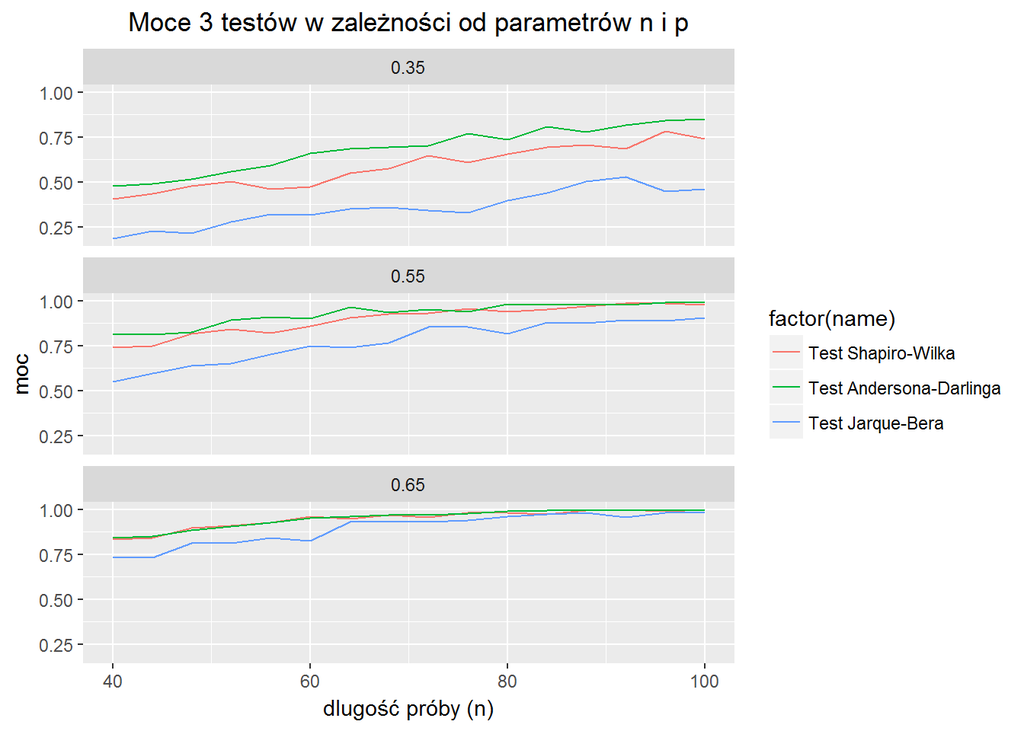

```r
power_df %>%
  ggplot(aes(x = n, y = power, color = factor(name))) +
  labs(title = "Moce 3 testów w zależności od parametrów n i p", x = "dlugość próby (n)", y = "moc") +
  theme(plot.title = element_text(hjust = 0.5)) +
  geom_line() +
  facet_wrap(~ p, nrow = 3)
```

**Interpretacja**  
W obu rozważanych przypadkach nie ma podstaw do odrzucenia hipotez zerowych, gdyż moc testu znacząco rośnie wraz ze zwiekszaniem długości próby (`n`) oraz wraz ze zwiększaniem prawdopodobieństwa wylosowania liczby z pierwszego rozkładu (`p`). Test Andersona-Darlinga cechuje się największą mocą, natomiast test Jarque-Bera wypada w tym przypadku najsłabiej.

#### 2. Badanie wpływu zmiany pierwszego elementu wektora par_1 na moc 3 testów

Obliczenie wykonane w poniższej analizie będą miały na celu stwierdzenie prawidłowości hipotezy:

*W zależności od zmiany wielkości pierwszego parametru wektora par_1:*  
H0: wraz ze zwiększaniem wielkości par_1[1] rośnie moc testu  
H1: wraz ze zwiększaniem wielkości par_1[1] maleje moc testu

Wprowadzenie wartości do poszczególnych zmiennych:

```r
#dlugość próby
n <- c(40, 100, 150)
#prawdopodobienstwo pierwszego rozkładu
p <- .65
#pierwsze elementy par_1 zmienne
paramki <- seq(2, 25, by = 1)
#parametry2
par_2 <- c(8, 3)
```

Powtórzenie wszystkich poleceń analogicznie jak wyżej.

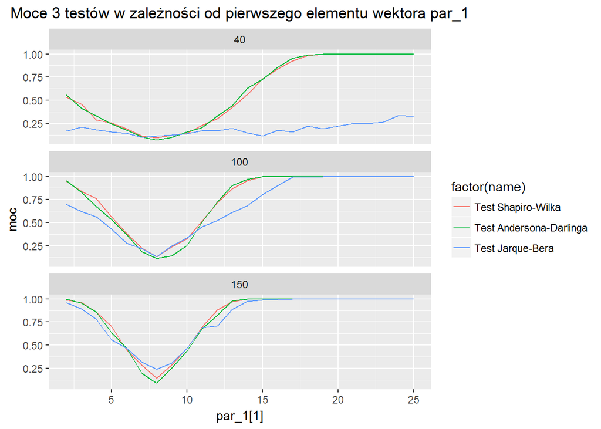

**Interpretacja**  
Zgodnie z przewidywaniami nie ma podstaw do odrzucenia hipotezy zerowej, moc testu maleje wraz ze zwiększaniem się pierwszwego elementu wektora par_1 dla wartości miejszych od `8` oraz rośnie wraz ze zwiększaniem się pierwszwego elementu wektora par_1 dla wartości większych od `8`. Moc jest najniższa w punkcie równym `8`, dzieje się tak ponieważ w tym miejscu wartości oczekiwane dwóch rozkładów są takie same, więc rozkłady nie różnią się znacząco. Dla długości próby równej `40` możemy zaobserować, że test Jarque-Bera cechuje się najmniejszą mocą.

#### 3. Badanie wpływu zmiany drugiego elementu wektora par_1 na moc 3 testów

Obliczenia wykonane w poniższej analizie będą miały na celu stwierdzenie prawidłowości hipotezy:

*W zależności od zmiany wielkości drugiego parametru wektora par_1:*  
H0: wraz ze zwiększaniem wielkości par_1[2] rośnie moc testu  
H1: wraz ze zwiększaniem wielkości par_1[2] maleje moc testu

Wprowadzenie wartości do poszczególnych zmiennych:

```r
#dlugość próby
n <- c(40, 100, 150)
#prawdopodobienstwo pierwszego rozkładu
p <- .65
#drugie elementy par_1 zmienne
paramki <- seq(5, 10, by = .15)
#parametry2
par_2 <- c(8, 3)
```

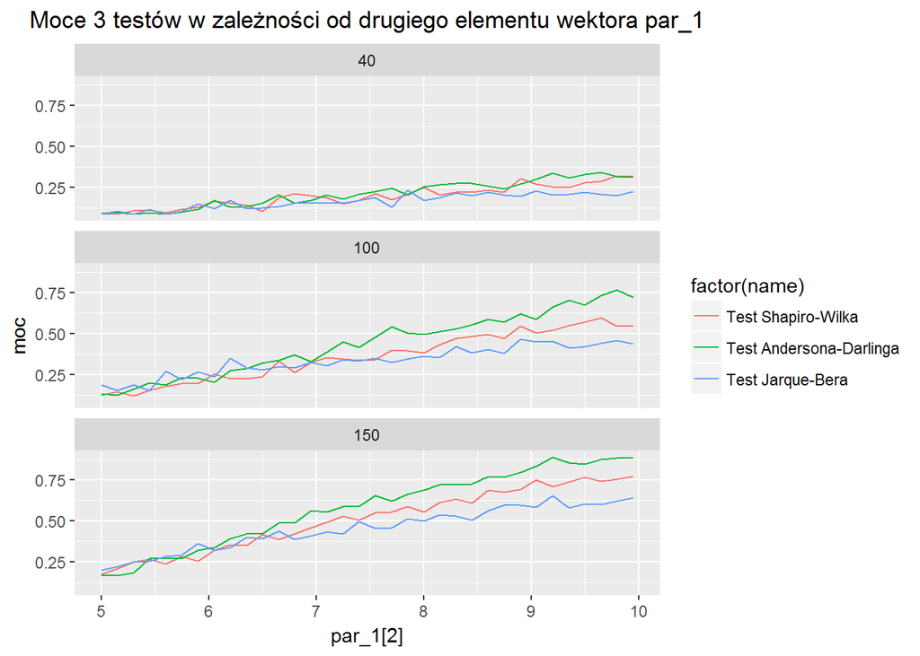

**Interpretacja**  
Nie ma podstaw do odrzucenia hipotezy H0, gdyż zmiana drugiego parametru pierwszego wektora (`par_1[2]`) powoduje stopniowy wzrost mocy testów. Najlepiej sprawdza się tutaj test Andersona-Darlinga, natomiast najsłabszy jest ponownie test Jarque-Bera.

#### 4. Badanie wpływu zmiany pierwszego elementu wektora par_2 na moc 3 testów

Obliczenia wykonane w poniższej analizy będą miały na celu stwierdzenie prawidłowości hipotezy:

*W zależności od zmiany wielkości pierwszego parametru wektora par_2:*  
H0: wraz ze zwiększaniem wielkości par_2[1] maleje moc testu  
H1: wraz ze zwiększaniem wielkości par_2[1] rośnie moc testu

Wprowadzenie wartości do poszczególnych zmiennych:

```r
#dlugość próby
n <- c(40, 100, 150)
#prawdopodobienstwo pierwszego rozkładu
p <- .65
#parametry1
par_1 <- c(7, 2)
#pierwsze elementy par_2 zmienne
paramki <- seq(3, 11, by = .2)
```

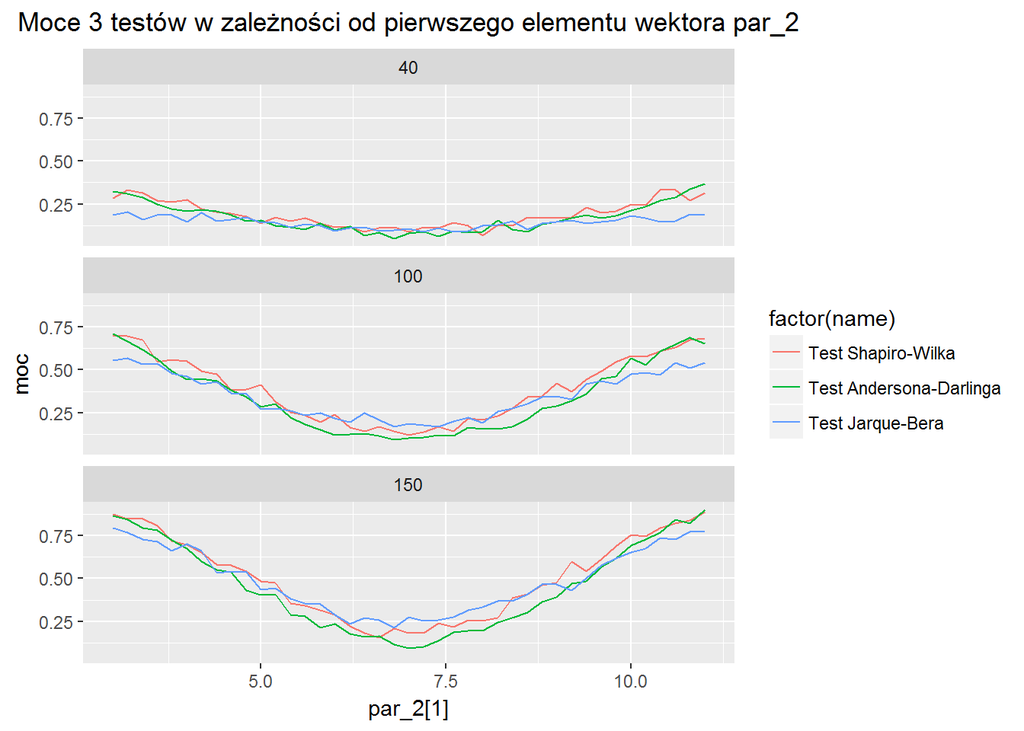

**Interpretacja**  
Są podstawy do odrzucenia hipotezy zerowej, gdyż zmiana pierwszego parametru drugiego wektora (`par_2[1]`) pododuje spadek mocy dla wartości zbliżających się do `7` z lewej strony praz stopniowy wzrost mocy dla wartości oddalających się od `7` z prawej. W punkcie, w którym wartości `par_1[1]` i `par_2[1]` są sobie równe moce testów zbliżają się do zera, co wynika z tego, że mieszany rozkład będzie prawie taki sam jak ten, z którym badamy zgodność. Wszystkie 3 testy mają podobną moc.

#### 5. Badanie wpływu zmiany drugiego elementu wektora par_2 na moc 3 testów

Obliczenia wykonane w poniższej analizie będą miały na celu stwierdzenie prawidłowości hipotezy:

*W zależności od zmiany wielkości drugiego parametru wektora par_2:*  
H0: wraz ze zwiększaniem wielkości par_2[2] maleje moc testu  
H1: wraz ze zwiększaniem wielkości par_2[2] rośnie moc testu

Wprowadzenie wartości do poszczególnych zmiennych:

```r
#dlugość próby
n <- c(40, 100, 150)
#prawdopodobienstwo pierwszego rozkładu
p <- .65
#parametry1
par_1 <- c(7, 3)
#drugie elementy par_2 zmienne
paramki <- seq(1, 5, by = .2)
```

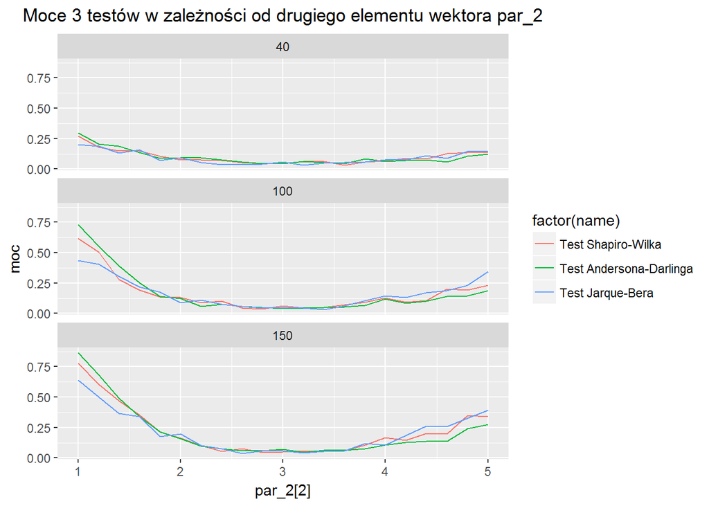

**Interpretacja**  
Są podstawy do odrzucenia hipotezy H0, gdyż zmiana drugiego parametru drugiego wektora (`par_2[2]`) pododuje spadek mocy dla wartości zbliżających się do `3` z lewej strony praz stopniowy wzrost mocy dla wartości oddalających się od `3` z prawej. Wszystkie 3 testy mają podobną moc.

**Wnioski ogólne**  
Porównując moce testów między sobą na podstawie powyższych wykresów, ciężko stwierdzić, który spośród nich cechuje się największą dokładnością. Jednak w większości przypadków test Jarque-Bera odznaczał się najmniejszą mocą, natomiast najbardziej dokłądny był test Andersona-Darlinga.

## Zadanie 3

Obliczenia wykonane w poniższej analizy będą miały na celu stwierdzenie prawidłowości następujących hipotez:

*W zależności od zmiany poziomu prawdopodobieństwa wystąpienia zmiennych z 1 rozkładu:*  
H0: wraz ze zwiększaniem prawdopodobieństwa maleje moc testu  
H1: wraz ze zwiększaniem prawdopodobieństwa rośnie moc testu

*W zależnosci od zmiany parametru par_2 - lambdy:*  
H0: wraz ze zwiekszaniem par_2 rośnie moc testu  
H1: wraz ze zwiekszaniem par_2 maleje moc testu

*W zależności od zmiany długości próby:*  
H0: wraz ze zwiększaniem długości próby rośnie moc testu  
H1: wraz ze zwiększaniem długości próby maleje moc testu

We wszystich przypadkach prawidłowym wynikiem powinien być brak podstaw do odrzucenia hipotez zerowych.

Wprowadzamy wartości do zmiennych.

```r
#ilość symulacji
N <- 200
#dlugości próby
n <- seq(40, 100, by = 15)
#typ rozkładu 1
family_1 <- "poisson"
#parametr stały
par_1 <- c(5)
#typ rozkładu 2
family_2 <- "poisson"
#parametr - lambda
par_2 <- c(1:25)
#prawdopodobienstwa
p <- c(.40, .55, .75)
```

Funkcją **expand.grid** tworzymy ramkę danych dla wszystich możliwych kombinacji zmiennych n, par_2 i p.

```r
params <- expand.grid(par_2 = par_2, p = p, n = n)
```

Po ustawieniu ziarna generatora na 20, dla każdej trójki danych z pomocą odpowiedniej funkcji **wilcox.test** obliczana jest moc testów i za pomocą **sapply** dołączana do wektora **powers**.

```r
set.seed(20)
powers <- sapply(1:nrow(params),
                 function(i){
                   par_2 <- params[i, 1]
                   p <- params[i, 2]
                   n <- params[i, 3]

                   p_vector <- sapply(rep(par_2, N), function(x){
                     sample_1 <- rmix(n, family_1, par_1, family_2, par_2, p)
                     sample_2 <- rpois(n, par_1[1])
                     wilcox.test(sample_1, sample_2, paired = T)$p.value
                    })
                   mean(p_vector < 0.05)
                 })
```

Tworzymy nową ramkę danych o nazwie **wilcox_df**, którą będziemy wykorzystywać do sporządzenia wykresów. Ramka danych zawierać będzie te same wartości co ramka **params** z dodatkową kolumną o nazwie **power**, zawierającą wyliczone wartości mocy dla każdej możliwej 3 danych.

```r
wilcox_df <- bind_cols(params, power = powers)
```

Za pomocą funkcji **ggplot** tworzymy wykres przedstawiający zależności pomiędzy n, par_2 oraz p.

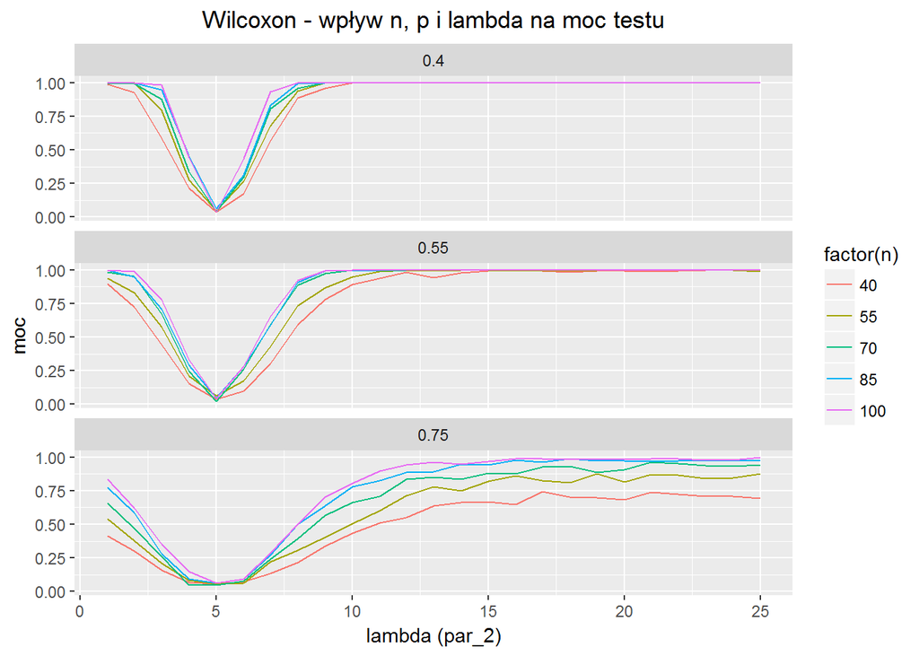

```r
wilcox_df %>%
  ggplot(aes(x = par_2, y = power, color = factor(n))) +
  labs(title = "Wilcoxon - wpływ n, p i lambda na moc testu", x = "lambda (par_2)", y = "moc") +
  theme(plot.title = element_text(hjust = 0.5)) +
  geom_line() +
  facet_wrap(~ p, nrow = 4)
```